# FML_Final Project

VaishnaviD

2024-04-25

## Assignment Purpose

The objectives of this assignment are threefold:  
1. To use real-world data  
2. To use the appropriate machine learning technique for the business problem, and  
3. To present the solution to top-level management.

## Project Objective and Information

Project Objective:- The main aim is to predict if a client will subscribe (yes/no) to a term deposit.

To load required library.

```r
library(dplyr)
library(class)
library(caret)
library(ggplot2)
library(lattice)
library(e1071)
library(rpart)
library(rattle)
library(corrplot)
```

To specify the file location.

```r
train <- read.csv("C:\\Users\\Vaishnavi\\OneDrive - Kent State University\\FML\\Final Project\\new_train.csv")
```

**Data Exploration**

To confirm that all the data has been properly imported.

```r
summary(train)
```

```
      age            job              marital           education
 Min.   :17.00   Length:32950       Length:32950       Length:32950
 1st Qu.:32.00   Class :character   Class :character   Class :character
 Median :38.00   Mode  :character   Mode  :character   Mode  :character
 Mean   :40.01
 3rd Qu.:47.00
 Max.   :98.00
   default            housing              loan             contact
 Length:32950       Length:32950       Length:32950       Length:32950
 Class :character   Class :character   Class :character   Class :character
 Mode  :character   Mode  :character   Mode  :character   Mode  :character



    month           day_of_week           duration         campaign
 Length:32950       Length:32950       Min.   :   0.0   Min.   : 1.000
 Class :character   Class :character   1st Qu.: 103.0   1st Qu.: 1.000
 Mode  :character   Mode  :character   Median : 180.0   Median : 2.000
                                       Mean   : 258.1   Mean   : 2.561
                                       3rd Qu.: 319.0   3rd Qu.: 3.000
                                       Max.   :4918.0   Max.   :56.000
     pdays          previous        poutcome              y
 Min.   :  0.0   Min.   :0.0000   Length:32950       Length:32950
 1st Qu.:999.0   1st Qu.:0.0000   Class :character   Class :character
 Median :999.0   Median :0.0000   Mode  :character   Mode  :character
 Mean   :962.1   Mean   :0.1747
 3rd Qu.:999.0   3rd Qu.:0.0000
 Max.   :999.0   Max.   :7.0000
```

```r
head(train)
```

```
  age          job  marital         education default housing loan   contact
1  49  blue-collar  married          basic.9y unknown      no   no  cellular
2  37 entrepreneur  married university.degree      no      no   no telephone
3  78      retired  married          basic.4y      no      no   no  cellular
4  36       admin.  married university.degree      no     yes   no telephone
5  59      retired divorced university.degree      no      no   no  cellular
6  29       admin.   single university.degree      no      no   no  cellular
  month day_of_week duration campaign pdays previous    poutcome   y
1   nov         wed      227        4   999        0 nonexistent  no
2   nov         wed      202        2   999        1     failure  no
3   jul         mon     1148        1   999        0 nonexistent yes
4   may         mon      120        2   999        0 nonexistent  no
5   jun         tue      368        2   999        0 nonexistent  no
6   aug         wed      256        2   999        0 nonexistent  no
```

```r
tail(train)
```

```
      age         job marital           education default housing loan
32945  29 blue-collar married            basic.6y      no      no   no
32946  28    services  single         high.school      no     yes   no
32947  52  technician married professional.course      no     yes   no
32948  54      admin. married            basic.9y      no      no  yes
32949  29      admin. married   university.degree      no      no   no
32950  35      admin. married   university.degree      no      no  yes
        contact month day_of_week duration campaign pdays previous    poutcome
32945  cellular   may         thu       16        7   999        0 nonexistent
32946  cellular   jul         tue      192        1   999        0 nonexistent
32947  cellular   nov         fri       64        1   999        1     failure
32948  cellular   jul         mon      131        4   999        0 nonexistent
32949 telephone   may         fri      165        1   999        0 nonexistent
32950 telephone   jun         tue      544        3   999        0 nonexistent
       y
32945 no
32946 no
32947 no
32948 no
32949 no
32950 no
```

```r
dim(train)
```

```
[1] 32950    16
```

```r
str(train)
```

```
'data.frame':   32950 obs. of  16 variables:
 $ age        : int  49 37 78 36 59 29 26 30 50 33 ...
 $ job        : chr  "blue-collar" "entrepreneur" "retired" "admin." ...
 $ marital    : chr  "married" "married" "married" "married" ...
 $ education  : chr  "basic.9y" "university.degree" "basic.4y" "university.degree" ...
 $ default    : chr  "unknown" "no" "no" "no" ...
 $ housing    : chr  "no" "no" "no" "yes" ...
 $ loan       : chr  "no" "no" "no" "no" ...
 $ contact    : chr  "cellular" "telephone" "cellular" "telephone" ...
 $ month      : chr  "nov" "nov" "jul" "may" ...
 $ day_of_week: chr  "wed" "wed" "mon" "mon" ...
 $ duration   : int  227 202 1148 120 368 256 449 126 574 498 ...
 $ campaign   : int  4 2 1 2 2 2 1 2 1 5 ...
 $ pdays      : int  999 999 999 999 999 999 999 999 999 999 ...
 $ previous   : int  0 1 0 0 0 0 0 0 0 0 ...
 $ poutcome   : chr  "nonexistent" "failure" "nonexistent" "nonexistent" ...
 $ y          : chr  "no" "no" "yes" "no" ...
```

Dataset contains two types of data. It has 5 numerical variables and 11 categorical variables.

**Data Prepartion/Cleaning**

```r
#To check if there are any missing/unknown values in the dataset
sum(complete.cases(train))
```

```
[1] 32950
```

```r
train.clean <- subset(train, !apply(train == "unknown", 1, any))
```

**No missing values were found but there were rows containing unknown data, which have been excluded**

To calculate Z-scores for numeric variables in a dataframe, find outliers by setting a Z-score threshold of 3 and remove rows with these outliers. This method helps remove extreme data points that might skew our analysis, ensuring our results are dependable.

```r
numeric_v <- c("age", "duration", "campaign", "pdays", "previous")
zscore <- scale(train[, numeric_v])
outliers <- apply(abs(zscore) > 3, 1, any)
outliers_i <- which(outliers)
train.1 <- train.clean[-outliers_i, ]
```

**Feature Selection**

Transforming categorical variables (for eg.marital status,education level,etc) which simplifies their analysis and interpretation in statistical models.

```r
train.1[c("marital","education","job", "default","housing","loan","contact","month","day_of_week","poutcome","y")] <- lapply(train.1[c("marital","education","job", "default","housing","loan","contact","month","day_of_week","poutcome","y")],factor)

# Applying conversion to numerical values to all factor variables
train.1[c("marital","education","job", "default","housing","loan","contact","month","day_of_week","poutcome","y")] <- lapply(train.1[c("marital","education","job", "default","housing","loan","contact","month","day_of_week","poutcome","y")], function(x) as.numeric(factor(x, levels = unique(x))))
```

Now lets create a linear regression model to predict the variable y using other variables in the dataset and assess the importance of each predictor by looking at the P value. (Lower P values indicate higher significance)

```r
lm_model <- lm(y ~ ., data = train.1)
summary(lm_model)
```

```
Call:
lm(formula = y ~ ., data = train.1)

Residuals:
     Min       1Q   Median       3Q      Max
-2.14242 -0.11801 -0.05008  0.01058  1.08081

Coefficients:
              Estimate Std. Error t value Pr(>|t|)
(Intercept)  1.029e+00  1.693e-01   6.079 1.23e-09 ***
age          1.121e-03  1.989e-04   5.635 1.78e-08 ***
job         -1.422e-03  7.960e-04  -1.787   0.0740 .
marital      1.422e-02  2.277e-03   6.245 4.30e-10 ***
education   -4.854e-03  1.171e-03  -4.144 3.42e-05 ***
default     -1.884e-02  1.632e-01  -0.115   0.9081
housing     -8.024e-04  3.840e-03  -0.209   0.8345
loan        -1.467e-03  5.241e-03  -0.280   0.7796
contact      7.071e-02  4.212e-03  16.789  < 2e-16 ***
month        1.620e-02  9.588e-04  16.899  < 2e-16 ***
day_of_week -3.100e-04  1.338e-03  -0.232   0.8167
duration     4.741e-04  7.341e-06  64.586  < 2e-16 ***
campaign    -1.656e-03  7.148e-04  -2.317   0.0205 *
pdays       -3.487e-04  2.237e-05 -15.586  < 2e-16 ***
previous     4.118e-02  7.797e-03   5.282 1.29e-07 ***
poutcome     4.939e-02  9.937e-03   4.970 6.74e-07 ***
---
Signif. codes:  0 '***' 0.001 '**' 0.01 '*' 0.05 '.' 0.1 ' ' 1

Residual standard error: 0.2825 on 22000 degrees of freedom
Multiple R-squared:  0.2712,    Adjusted R-squared:  0.2707
F-statistic: 545.7 on 15 and 22000 DF,  p-value: < 2.2e-16
```

Using ANOVA to evaluate the significance of the fitted model by comparing it to a simpler model and checking if the predictors together significantly impact the outcome.

```r
anova(lm_model)
```

```
Analysis of Variance Table

Response: y
               Df  Sum Sq Mean Sq   F value    Pr(>F)
age             1    5.20    5.20   65.1758 7.199e-16 ***
job             1    2.12    2.12   26.5085 2.646e-07 ***
marital         1    9.02    9.02  112.9411 < 2.2e-16 ***
education       1    2.80    2.80   35.0454 3.269e-09 ***
default         1    0.03    0.03    0.3358   0.56224
housing         1    0.09    0.09    1.1657   0.28030
loan            1    0.00    0.00    0.0206   0.88581
contact         1   44.27   44.27  554.6322 < 2.2e-16 ***
month           1   47.14   47.14  590.5235 < 2.2e-16 ***
day_of_week     1    0.03    0.03    0.3960   0.52915
duration        1  355.97  355.97 4459.5018 < 2.2e-16 ***
campaign        1    1.35    1.35   16.9154 3.923e-05 ***
pdays           1  183.03  183.03 2292.9617 < 2.2e-16 ***
previous        1    0.37    0.37    4.5913   0.03215 *
poutcome        1    1.97    1.97   24.7031 6.738e-07 ***
Residuals   22000 1756.11    0.08
---
Signif. codes:  0 '***' 0.001 '**' 0.01 '*' 0.05 '.' 0.1 ' ' 1
```

```r
train.1 <- train.1[,-c(5,6,7,10,14)]
```

Now lets make corrplot :

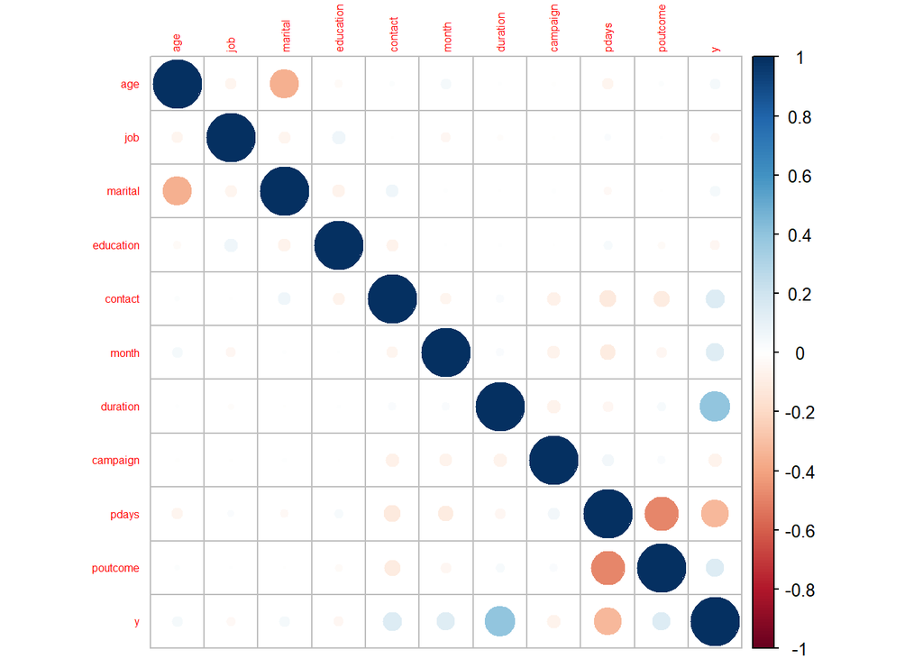

```r
cor = cor(train.1)
corrplot(cor, method = "circle",tl.cex=0.5)
```

The corrplot shows that no two independent variables have a high correlation, either positive or negative. This means there is no issue of multicollinearity, so we are not removing any variables.

**Descriptive Statistics** Boxplot - Plotting boxplot for all numerical variables.  
Pdays is a variable with 26 categories so we will exclude it from the boxplots.

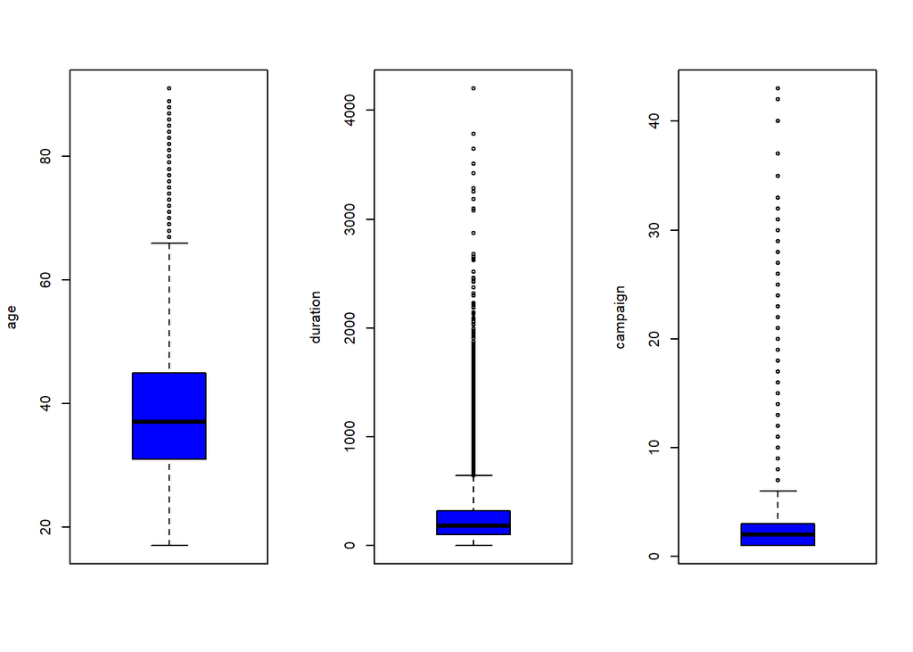

```r
par(ask = FALSE, mfrow = c(1,3))
for (variable in c("age", "duration", "campaign")) {
  boxplot(train.1[[variable]], col =  "blue", ylab = variable)
}
```

Histogram - Plotting histrogram for all variables

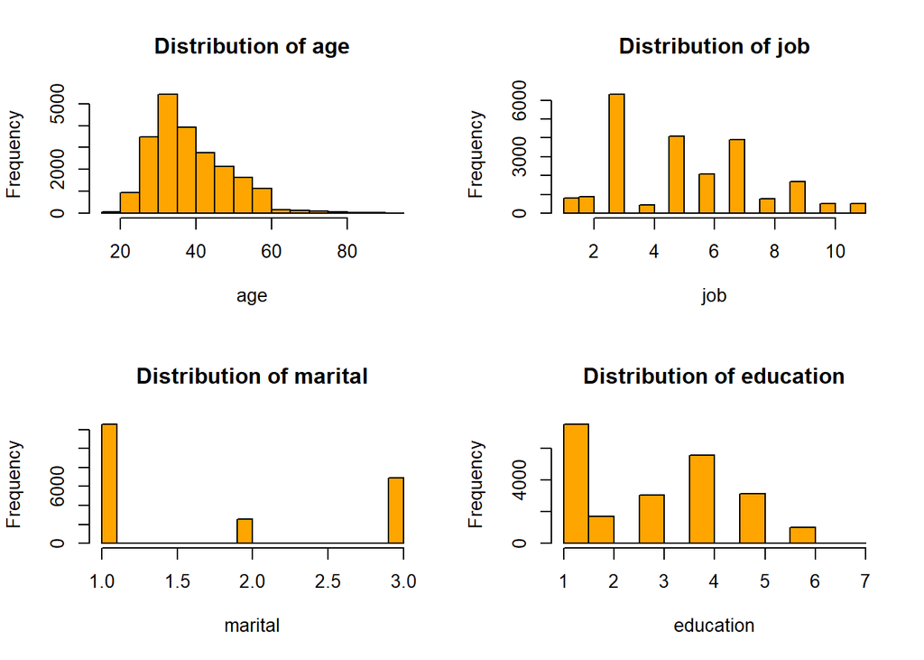

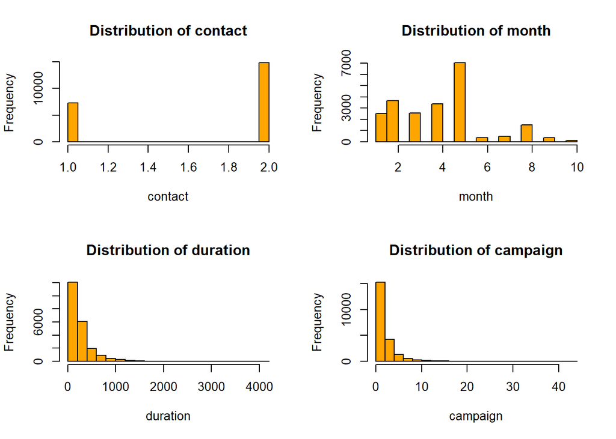

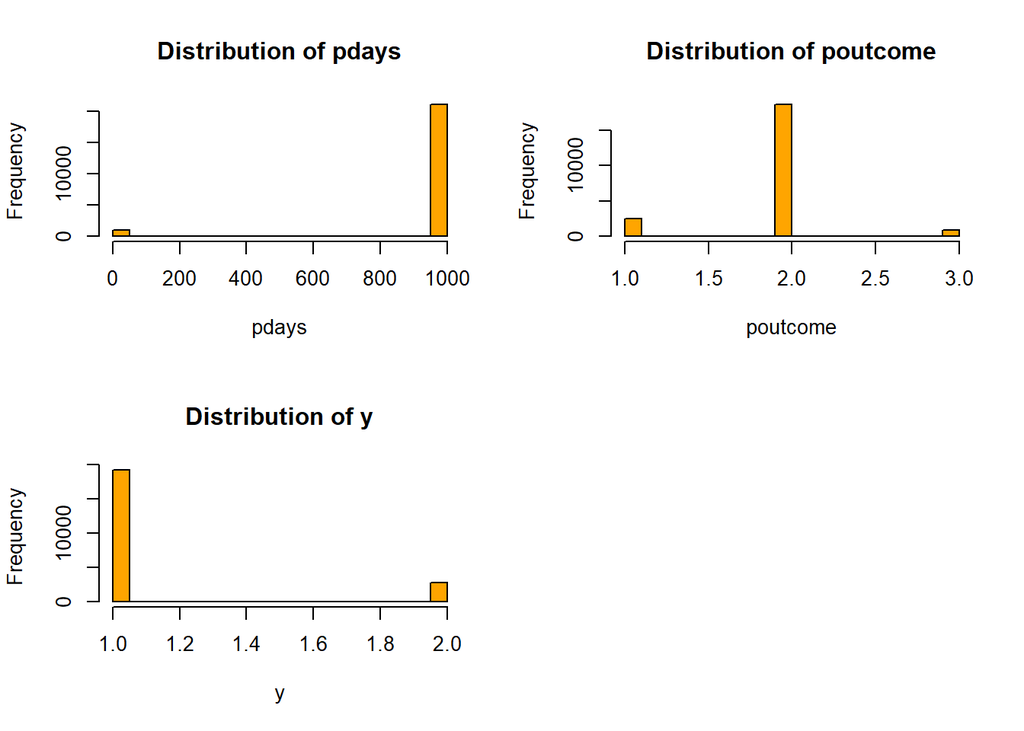

```r
par(mfrow=c(2,2))
for (i in 1:ncol(train.1)) {
  hist(train.1[, i], freq = TRUE, main = paste("Distribution of", colnames(train.1)[i]), xlab = colnames(train.1)[i], col = "orange")
}
```

**Predictive Analytics**

Let’s Normalize the data for further analysis and transforming categorical variables into dummy variables

```r
norm_data <- preProcess(train.1[,c("age","duration","campaign","pdays")], method = c("center", "scale"))

train.1[,c("age","duration","campaign","pdays") ] <- predict(norm_data, newdata = train.1[,c("age","duration","campaign","pdays")])
```

```r
train.1[c("marital","education","job","contact","month","poutcome","y")] = lapply(train.1[c("marital","education","job","contact","month","poutcome","y")],factor)
train.cy = train.1[c("contact","y")]
dummy_data <- dummyVars(~.-contact-y, data = train.1)
train.1 <-as.data.frame(predict(dummy_data,train.1))
train.1 = cbind(train.1,train.cy)
```

Lets make training and testing datasets : Now partitioning the data into training (70%) and testing (30%) set.

```r
set.seed(150)
train_index <- createDataPartition(train.1$y, p = 0.7, list = FALSE)
training.df <- train.1[train_index, ]
test.df <- train.1[-train_index, ]
dim(training.df)
```

```
[1] 15412    40
```

```r
dim(test.df)
```

```
[1] 6604   40
```

## Naive Baye’s Classifier

Now lets train the Naive Bayes Model, Predict on validation data and evaluate the predictions.

```r
nb_model <- naiveBayes(y ~ ., data = training.df)
test_predictions <- predict(nb_model, test.df)
confusionMatrix(as.factor(test_predictions), as.factor(test.df$y))
```

```
Confusion Matrix and Statistics

          Reference
Prediction    1    2
         1 5290  421
         2  488  405

               Accuracy : 0.8624
                 95% CI : (0.8538, 0.8706)
    No Information Rate : 0.8749
    P-Value [Acc > NIR] : 0.99892

                  Kappa : 0.3922

 Mcnemar's Test P-Value : 0.02859

            Sensitivity : 0.9155
            Specificity : 0.4903
         Pos Pred Value : 0.9263
         Neg Pred Value : 0.4535
             Prevalence : 0.8749
         Detection Rate : 0.8010
   Detection Prevalence : 0.8648
      Balanced Accuracy : 0.7029

       'Positive' Class : 1
```

The model’s accuracy is about 86.24%, meaning it gets most predictions right. The model exhibits high sensitivity (True Positive Rate) of 91.55% which indicates that it correctly identifies a high proportion of actual positive instances.The specificity (True Negative Rate) is relatively low at 49.03% which says that the model has difficulty in correctly identiyfying negative instances. True positives and true negatives show how well the model sorts each class correctly, while false positives and false negatives reveal where it messes up. To improve accuracy, the model might need some adjustments to reduce these mistakes and improve the overall accuracy.

## KNN - classifier

Now let’s find the best k value to reach high accuracy.

```r
accuracy <- data.frame(k = seq(1, 15, 1), overallaccuracy = rep(0, 15))
for(i in 1:30) {
pred <- class::knn(train = training.df, test = test.df, cl = training.df$y, k = i)
accuracy[i, 2] <- confusionMatrix(pred, as.factor(test.df$y),positive = "1")$overall[1]
}
which(accuracy[,2] == max(accuracy[,2]))
```

```
[1] 7
```

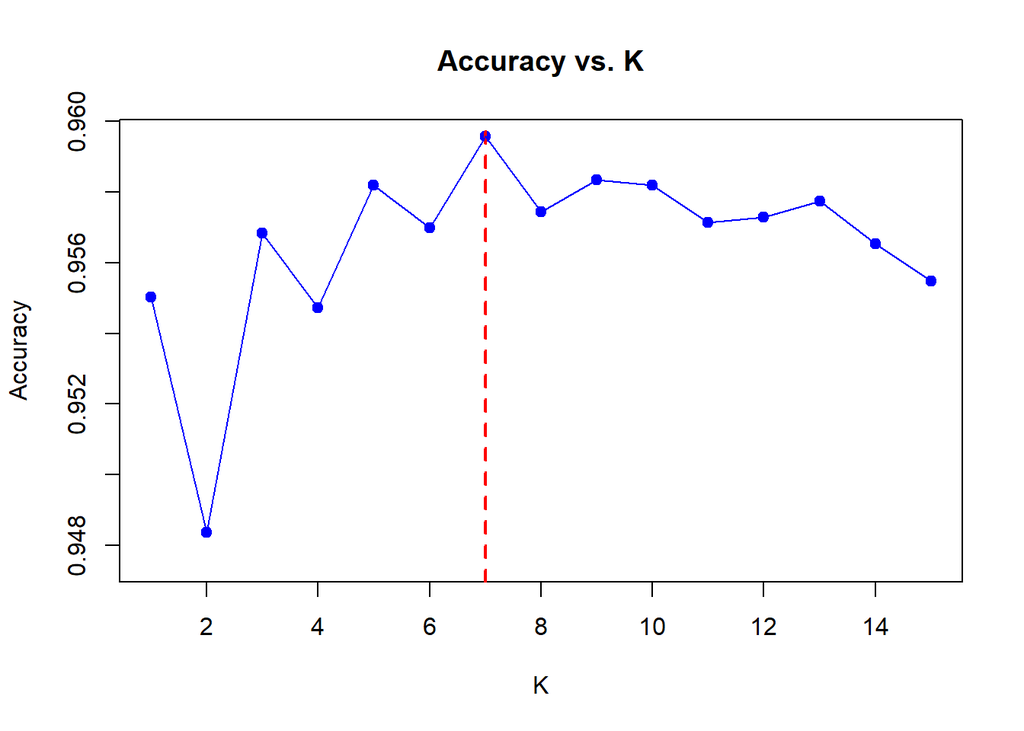

```r
# Plotting the scatter points
plot(accuracy$k, accuracy$overallaccuracy,col = "blue", pch = 19,
     xlab = "K", ylab = "Accuracy", main = "Accuracy vs. K")
abline(v = 7, col = "red", lwd = 2, lty = 2)

# Adding the line plot
lines(accuracy$k, accuracy$overallaccuracy, col = "blue")
```

As shown in the graph, we find that the best k value is 7. Next, we’ll use the k-nearest neighbors (kNN) technique to classify items in the test group. Then, we’ll make a confusion matrix to gauge the accuracy and effectiveness of the classification model.

```r
pred_1 <- class::knn(train = training.df, test = test.df, cl = training.df$y, k = 7)
confusionMatrix(as.factor(pred_1),as.factor(test.df$y))
```

```
Confusion Matrix and Statistics

          Reference
Prediction    1    2
         1 5730  219
         2   48  607

               Accuracy : 0.9596
                 95% CI : (0.9545, 0.9642)
    No Information Rate : 0.8749
    P-Value [Acc > NIR] : < 2.2e-16

                  Kappa : 0.7973

 Mcnemar's Test P-Value : < 2.2e-16

            Sensitivity : 0.9917
            Specificity : 0.7349
         Pos Pred Value : 0.9632
         Neg Pred Value : 0.9267
             Prevalence : 0.8749
         Detection Rate : 0.8677
   Detection Prevalence : 0.9008
      Balanced Accuracy : 0.8633

       'Positive' Class : 1
```

The model boasts an impressive accuracy of 95.96%, meaning it accurately predicts the class for most cases. It shows a high sensitivity (True Positive Rate) of 99.17% and a moderate specificity (True Negative Rate) of 73.49%. This indicates that it’s good at spotting true positives and handling false positives fairly well.

## Conclusion

The main goal of the project is to find the best model for our dataset. We tested two algorithms: Naive Bayes and KNN. Although Naive Bayes showed high sensitivity, the KNN model performed better overall, with higher accuracy and better specificity. So, we chose the KNN model as the best option for predicting potential term deposit subscribers among existing bank customers.